# Summative Assessment 1

Elisha Borromeo and Zyann Lynn Mayo

2025-03-16

## **1. Probability of Product Defectivity**

Here, we’ll use the Law of Total Probability. The probability of selecting a defective product is calculated as:

$$P(D) = (x_1 \times y_1) + (x_2 \times y_2) + (x_3 \times y_3)$$

where:  
- $x_i$ are the **production proportions** (must be equal to 1 when added).  
- $y_i$ are the **defect rates** (must be equal to 0.12 when added).  
- The values must satisfy the conditions:  
- $0.10 \leq x_i \leq 0.40$  
- $0.01 \leq y_i \leq 0.05$

```r
library(shiny)
ui <- fluidPage(
  titlePanel("Defective Probability Calculator"),

  sidebarLayout(
    sidebarPanel(
      numericInput("x1", "Enter x1:", value = NA, min = 0.10, max = 0.40),
      numericInput("x2", "Enter x2:", value = NA, min = 0.10, max = 0.40),
      numericInput("x3", "Enter x3:", value = NA, min = 0.10, max = 0.40),

      numericInput("y1", "Enter y1:", value = NA, min = 0.01, max = 0.05),
      numericInput("y2", "Enter y2:", value = NA, min = 0.01, max = 0.05),
      numericInput("y3", "Enter y3:", value = NA, min = 0.01, max = 0.05),

      actionButton("calculate", "Compute Probability")
    ),

    mainPanel(
      verbatimTextOutput("result")
    )
  )
)

server <- function(input, output, session) {
  observeEvent(input$calculate, {
    x <- c(input$x1, input$x2, input$x3)
    y <- c(input$y1, input$y2, input$y3)

    # Here we can check if the user has enetered values
    if (any(is.na(x)) || any(is.na(y))) {
      output$result <- renderText("Please enter all values before calculating.")
      return()
    }

    # This is the code that ensures that the user inputs satisfy the given conditions
    if (any(x < 0.10 | x > 0.40)) {
      output$result <- renderText("Error: x values must be between 0.10 and 0.40.")
      return()
    }
    if (any(y < 0.01 | y > 0.05)) {
      output$result <- renderText("Error: y values must be between 0.01 and 0.05.")
      return()
    }
    if (sum(x) != 1) {
      output$result <- renderText("Error: x1 + x2 + x3 should be equal to 1.")
      return()
    }
    if (sum(y) != 0.12) {
      output$result <- renderText("Error: y1 + y2 + y3 should be equal to 0.12.")
      return()
    }

    # We can compute probability using Law of Total Probability
    p_defective <- sum(x * y)

    output$result <- renderText(paste("Probability of selecting a defective product:", round(p_defective, 4)))

    # Let's reset so that user can input again eventually
    updateNumericInput(session, "x1", value = NA)
    updateNumericInput(session, "x2", value = NA)
    updateNumericInput(session, "x3", value = NA)
    updateNumericInput(session, "y1", value = NA)
    updateNumericInput(session, "y2", value = NA)
    updateNumericInput(session, "y3", value = NA)
  })
}

shinyApp(ui, server)
```

Shiny applications not supported in static R Markdown documents

## **2. Univariate Discrete Random Variable**

```r
library(shiny)
library(ggplot2)

ui_uni <- fluidPage(
    titlePanel("Univariate Random Variable"),

    sidebarLayout(
        sidebarPanel(
            textInput("xvals", "Enter X values (comma-separated):", ""),
            textInput("probs", "Enter probabilities (comma-separated):", ""),
            actionButton("compute", "Compute")  # Button to trigger computation
        ),

        mainPanel(
            verbatimTextOutput("stats"),
            plotOutput("pdf_plot"),
            plotOutput("cdf_plot")
        )
    )
)

server_uni <- function(input, output) {
    observeEvent(input$compute, {
        if (input$xvals == "" || input$probs == "") {
            output$stats <- renderText("Error: Please enter values for X and probabilities.")
            return()
        }

        X <- as.numeric(unlist(strsplit(input$xvals, ",")))
        P <- as.numeric(unlist(strsplit(input$probs, ",")))

        # This is where we can ensure that user input of probabilities, when added together, will be equal to 1 and are in [0,1]
        if (sum(P) != 1) {
            output$stats <- renderText("Error: Probabilities' sum must be equal to 1.")
            return()
        }
        if (any(P < 0 | P > 1)) {
            output$stats <- renderText("Error: Probabilities must be between 0 and 1.")
            return()
        }

        # This is where we compute the mean and variance
        mean_X <- sum(X * P)
        variance_X <- sum((X - mean_X)^2 * P)
        output$stats <- renderText(paste("Mean:", round(mean_X, 4),
                                         "\nVariance:", round(variance_X, 4)))

        # Plotting PDF:
        output$pdf_plot <- renderPlot({
            ggplot(data.frame(X, P), aes(x = X, y = P)) +
                geom_bar(stat = "identity", fill = "purple") +
                labs(title = "Probability Mass Function (PMF)", x = "X", y = "P(X)") +
                theme_minimal()
        })

        # Let us now calculate CDF
        cdf_values <- cumsum(P)

        # Plotting CDF:
        output$cdf_plot <- renderPlot({
            ggplot(data.frame(X, CDF = cdf_values), aes(x = X, y = CDF)) +
                geom_step(color = "purple", size = 1) +
                labs(title = "Cumulative Distribution Function (CDF)", x = "X", y = "F(X)") +
                theme_minimal()
        })
    })
}

shinyApp(ui_uni, server_uni)
```

Shiny applications not supported in static R Markdown documents

## **Bivariate Discrete Random Variable**

```r
library(shiny)

ui <- fluidPage(
    titlePanel("Bivariate Discrete Random Variable"),
    sidebarLayout(
        sidebarPanel(
            textInput("xvals", "Enter X values (comma-separated)", ""),
            textInput("yvals", "Enter Y values (comma-separated)", ""),
            textAreaInput("probs", "Enter joint probabilities (row-wise)", ""),
            actionButton("compute", "Compute")
        ),
        mainPanel(
            tableOutput("marginals"),
            tableOutput("cond_x_given_y"),
            tableOutput("cond_y_given_x"),
            plotOutput("pdf_plot"),
            plotOutput("cond_plot")
        )
    ),
)

server <- function(input, output) {
    observeEvent(input$compute, {
        # We must ensure that user input is not empty
        if (input$xvals == "" || input$yvals == "" || input$probs == "") {
            showNotification("Error: Please enter all required values.", type = "error")
            return()
        }

        X <- as.numeric(unlist(strsplit(input$xvals, ",")))
        Y <- as.numeric(unlist(strsplit(input$yvals, ",")))

        probs_text <- gsub("\n", ",", input$probs)
        probs_vector <- as.numeric(unlist(strsplit(probs_text, ",")))

        # Makes sure that dimensions are correct
        expected_length <- length(X) * length(Y)

        if (length(probs_vector) != expected_length) {
            showNotification(
                paste("Error: Probability matrix should have", expected_length,
                      "values, but got", length(probs_vector)),
                type = "error"
            )
            return()
        }

        # Here's our probability matrix
        probs <- matrix(probs_vector, nrow = length(X), byrow = TRUE)

        # Marginal Distributions
        P_X <- rowSums(probs)
        P_Y <- colSums(probs)

        # Conditional Distributions
        P_X_given_Y <- sweep(probs, 2, P_Y, FUN = "/")  # P(X | Y) = P(X, Y) / P(Y)
        P_Y_given_X <- sweep(probs, 1, P_X, FUN = "/")  # P(Y | X) = P(X, Y) / P(X)

        P_X_given_Y[is.nan(P_X_given_Y)] <- 0
        P_Y_given_X[is.nan(P_Y_given_X)] <- 0

        # Marginal Probability Table
        output$marginals <- renderTable({
            data.frame(X = X, P_X = P_X, Y = c(Y, rep(NA, length(X) - length(Y))), P_Y = c(P_Y, rep(NA, length(X) - length(Y))))
        }, rownames = FALSE)

        # Conditional Probabilities Table
        output$cond_x_given_y <- renderTable({
            cond_table <- as.data.frame(round(P_X_given_Y, 3))
            colnames(cond_table) <- paste("P(X | Y =", Y, ")", sep = "")
            cbind(X = X, cond_table)
        }, rownames = FALSE)

        output$cond_y_given_x <- renderTable({
            cond_table <- as.data.frame(round(P_Y_given_X, 3))
            colnames(cond_table) <- paste("P(Y | X =", X, ")", sep = "")
            cbind(Y = Y, cond_table)
        }, rownames = FALSE)

        # Marginal Distributions Bar Plot
        output$pdf_plot <- renderPlot({
            par(mfrow = c(1, 2))  # Side-by-side plots

            barplot(P_X, names.arg = X, col = "pink", main = "Marginal Distribution P(X)", xlab = "X", ylab = "P(X)")
            barplot(P_Y, names.arg = Y, col = "lightblue", main = "Marginal Distribution P(Y)", xlab = "Y", ylab = "P(Y)")
        })

        # Conditional Distribution Plots
        output$cond_plot <- renderPlot({
            par(mfrow = c(1, 2))

            matplot(X, t(P_X_given_Y), type = "b", pch = 19, col = rainbow(length(Y)), lty = 1,
                    main = "Conditional Distribution P(X | Y)", xlab = "X", ylab = "P(X | Y)")
            legend("topright", legend = paste("Y =", Y), col = rainbow(length(Y)), pch = 19)

            matplot(Y, P_Y_given_X, type = "b", pch = 19, col = rainbow(length(X)), lty = 1,
                    main = "Conditional Distribution P(Y | X)", xlab = "Y", ylab = "P(Y | X)")
            legend("topright", legend = paste("X =", X), col = rainbow(length(X)), pch = 19)
        })
    })
}

shinyApp(ui, server)
```

Shiny applications not supported in static R Markdown documents

## **3. Markov Property**

Based on the given, let us first generate 10,000 searches going through a list of sites until the key phrase is found.

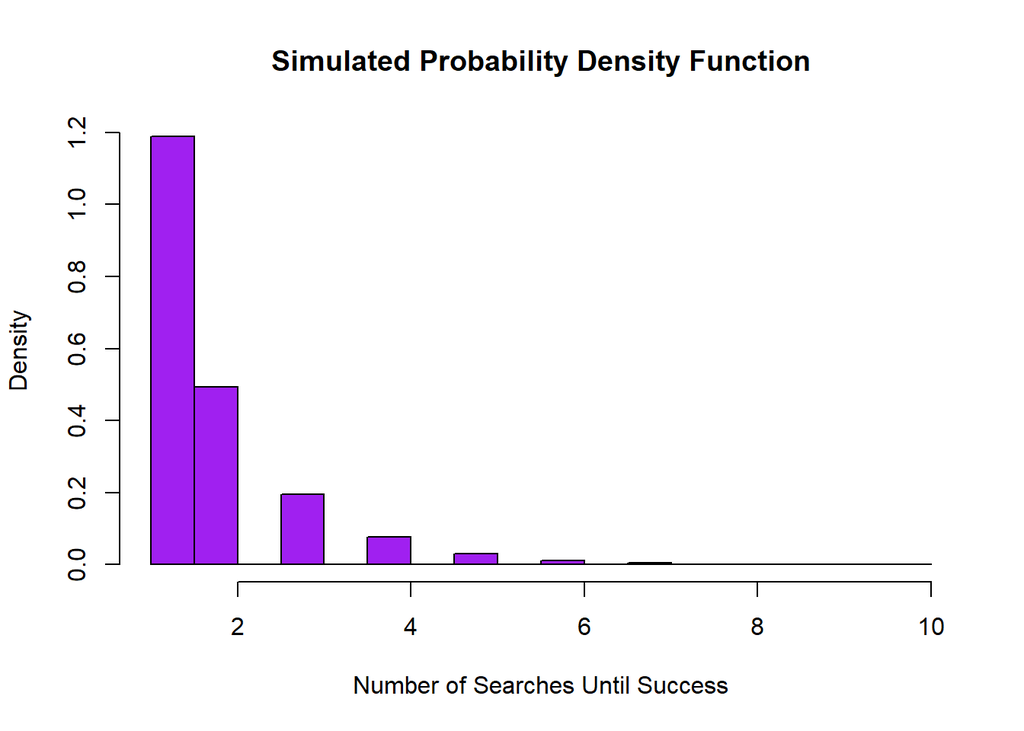

```r
set.seed(920)
searches <- 10000
p <- 0.6
simulation <- rgeom(searches, p) + 1 #generated values should start from 1

hist(simulation, probability = TRUE, breaks = 30,
     main = "Simulated Probability Density Function",
     xlab = "Number of Searches Until Success",
     col = "purple", border = "black")
```

Then, we compute the mean and variance:

```r
mean_sim <- mean(simulation)
var_sim <- var(simulation)
```

Which gives us the values **1.67** for the **mean**, and **1.08** for the **variance**.

### **Obtain the simulated conditional distribution of searches where three searches have been carried out without success.**

```r
cond_sim <- simulation[simulation > 3]
mean_cond <- mean(cond_sim)
var_cond <- var(cond_sim)
```

After the condition, we get the values: **Mean =4.65**, **Variance = 1.07**.

### **Markov memoryless property**

According to the markov property of the geometric distribution, if X is a geometric random variable, then for each integer n:

```r
p_x4_given_x3 <- sum(simulation == 4) / sum(simulation > 3)
p_x1 <- mean(simulation == 1)
```

These values show that the Markov property hold as the values are **approximately** equal to each other.

P(X = 4|X >3) = **0.61**

P(X = 1) = **0.59**

**(b) P(X = 5|X >3) and P(X = 2)**

```r
p_x5_given_x3 <- sum(simulation == 5) / sum(simulation > 3)
p_x2 <- mean(simulation == 2)
```